# Financial Crisis vs COVID Crisis

- Show All Code
- Hide All Code

Sector & Economic Insights

Author

Brock Ellis

# Data Import

```r
library(tidyverse)
library(tidyquant)
library(scales)
library(dygraphs)
library(xts)
library(ggrepel)
```

```r
# Define tickers and FRED series
tickers <- c("XLK", "VFH", "XLV", "XLY", "XLP", "XLI", "XLE", "XLB", "IXJ", "XLU", "VNQ")
fred_series <- c(
  "UNRATE", "FEDFUNDS", "PAYEMS", "CPIAUCSL", "INDPRO", "PERMIT", "M2SL", "GS1", "UMCSENT"
)

# Get Stock Data
data <- tq_get(tickers, get = "stock.prices", from = "2000-01-01")

# Get FRED Data
fred_data_long <- tq_get(
  fred_series,
  get = "economic.data",
  from = "2000-01-01"
)

# Convert FRED data to wide format
fred_data_wide <- fred_data_long %>%
  pivot_wider(
    names_from = symbol,
    values_from = price
  )
```

```r
# Key Global Indicators: US Dollar Index (DEXUSEU) and Crude Oil (WTISPLC)
# DEXUSEU is EUR/USD, and WTISPLC is WTI Spot Price.
global_tickers <- c("DEXUSEU", "WTISPLC")

global_data_long <- tq_get(
  global_tickers,
  get = "economic.data",
  from = "2000-01-01"
)

global_data_wide <- global_data_long %>%
  pivot_wider(
    names_from = symbol,
    values_from = price
  )

# Combine FRED and Global Data for a comprehensive macro dataset
macro_data_wide <- fred_data_wide %>%
  left_join(global_data_wide, by = "date")

# Replace the old fred_data_wide with the new macro_data_wide for later steps
fred_data_wide <- macro_data_wide
```

```r
# Calculate Monthly Log Returns
sector_returns_monthly <- data %>%
  group_by(symbol) %>%
  tq_transmute(
    select = adjusted,
    mutate_fun = periodReturn,
    period = "monthly",
    type = "log" # Log returns for statistical analysis
  ) %>%
  rename(monthly_log_return = monthly.returns)

# Define the Ticker-to-Sector Mapping
sector_map <- c(
 "XLK" = "Technology",
 "VFH" = "XL_Financials",
 "XLV" = "Health Care",
 "XLY" = "Consumer Discretionary",
 "XLP" = "Consumer Staples",
 "XLI" = "Industrials",
 "XLE" = "Energy",
 "XLB" = "Materials",
 "IXJ" = "Communication Services",
 "XLU" = "Utilities",
 "VNQ" = "Real Estate"
)

# Calculate Monthly Log Returns, using the full Sector Name
sector_returns_monthly <- data %>%
  # Apply the mapping to the 'symbol' column
  mutate(symbol = sector_map[symbol]) %>%
  group_by(symbol) %>%
  tq_transmute(
    select = adjusted,
    mutate_fun = periodReturn,
    period = "monthly",
    type = "log"
  ) %>%
  rename(monthly_log_return = monthly.returns)


# Calculate Year-over-Year (YoY) Change for economic indicators
fred_data_analysis <- fred_data_wide %>%
  mutate(
    PAYEMS_YoY = (PAYEMS / lag(PAYEMS, 12) - 1) * 100,
    CPIAUCSL_YoY = (CPIAUCSL / lag(CPIAUCSL, 12) - 1) * 100,
    UNRATE_Level = UNRATE,
    FEDFUNDS_Level = FEDFUNDS,
    UMCSENT_Level = UMCSENT
  ) %>%
  select(date, UNRATE_Level, FEDFUNDS_Level, PAYEMS_YoY, CPIAUCSL_YoY, UMCSENT_Level)
```

```r
# Define the exact crisis periods
crisis_periods <- list(
  Financial = c("2007-09-01", "2009-06-30"),
  COVID     = c("2020-02-01", "2021-09-30")
)

# Function to calculate performance metrics
calculate_crisis_performance <- function(data, start_date, end_date) {

  # Filter and prepare data for nesting
  crisis_data <- data %>%
    filter(date >= as.Date(start_date) & date <= as.Date(end_date)) %>%
    # Convert monthly log returns to simple returns (DO NOT MES WITH THIS)
    mutate(simple_return = exp(monthly_log_return) - 1) %>%
    select(date, symbol, simple_return)

  # SNest the data by symbol
  nested_data <- crisis_data %>%
    group_by(symbol) %>%
    nest()

  # Run the calculation using map_dbl (return as type double)
  performance_metrics <- nested_data %>%
    mutate(
      Mean_Return = map_dbl(data, ~ mean(log(.x$simple_return + 1), na.rm = TRUE)),
      Std_Dev = map_dbl(data, ~ sd(log(.x$simple_return + 1), na.rm = TRUE)),

      # convrt the nested tibble to an xts object BEFORE!!!! calculating maxDrawdown
      Max_Drawdown = map_dbl(data, function(df) {
        returns_xts <- xts(x = df$simple_return, order.by = df$date)

        return(maxDrawdown(returns_xts) * 100)
      })
    ) %>%
    select(symbol, Mean_Return, Std_Dev, Max_Drawdown)

  return(performance_metrics)
}


# Apply the function to both crises and combine results
sector_performance_combined <- bind_rows(
  calculate_crisis_performance(sector_returns_monthly, crisis_periods$Financial[1], crisis_periods$Financial[2]) %>%
    mutate(Crisis = "Financial Crisis"),
  calculate_crisis_performance(sector_returns_monthly, crisis_periods$COVID[1], crisis_periods$COVID[2]) %>%
    mutate(Crisis = "COVID-19 Crisis")
)
```

# Introduction

This project examines how U.S. equity sectors and key macroeconomic indicators behaved during two major market disruptions: the Global Financial Crisis (2007–2009) and the COVID-19 shock (2020).

Using sector-level returns, drawdowns, volatility, and cross-sector correlations, the analysis highlights fundamental differences in the severity, duration, and synchronization of market stress across the two episodes. In addition, macroeconomic indicators such as unemployment, monetary policy, inflation, and consumer sentiment provide critical context for understanding these market dynamics.

Together, the results illustrate how a prolonged, systemic financial collapse contrasts with a sudden, policy-driven economic shock, offering insight into risk management and diversification under extreme conditions.

# Sector Performance Analysis

## Maximum Drawdown Comparison

This chart highlights a clear difference in the severity and breadth of losses across sectors during the two crises. The Financial Crisis (blue bars) produced consistently deeper maximum drawdowns across every sector, with many experiencing losses in the 40–70% range, underscoring the systemic and prolonged nature of the shock. Sectors such as Financials, Real Estate, Materials, and Industrials were especially hard hit, reflecting the crisis’s roots in the financial system and its spillover into the real economy.

In contrast, the COVID-19 Crisis (green bars) resulted in shallower maximum drawdowns overall, generally between 10–45%, and showed greater dispersion across sectors. Defensive sectors like Communication Services and Health Care were relatively resilient, while cyclicals such as Energy and Consumer Discretionary saw larger declines. Together, the comparison illustrates that while COVID-19 triggered a sharp and sudden sell-off, the Global Financial Crisis imposed deeper, more uniform damage across the market, revealing far greater systemic vulnerability.

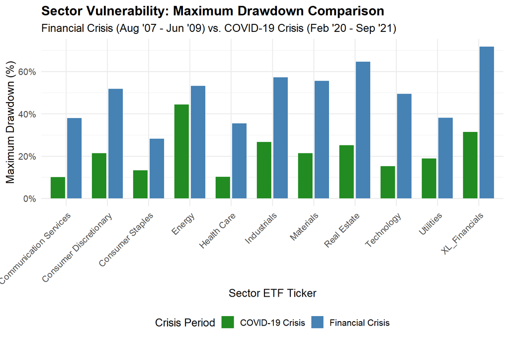

```r
# Max Drawdown Bar Chart
ggplot(sector_performance_combined, aes(x = symbol, y = Max_Drawdown, fill = Crisis)) +
  geom_bar(stat = "identity", position = position_dodge(width = 0.8), width = 0.7) +
  labs(
    title = "Sector Vulnerability: Maximum Drawdown Comparison",
    subtitle = "Financial Crisis (Aug '07 - Jun '09) vs. COVID-19 Crisis (Feb '20 - Sep '21)",
    x = "Sector ETF Ticker",
    y = "Maximum Drawdown (%)",
    fill = "Crisis Period"
  ) +
  scale_y_continuous(labels = function(x) paste0(x, "%")) +
  scale_fill_manual(values = c("Financial Crisis" = "steelblue", "COVID-19 Crisis" = "forestgreen")) +
  theme_minimal(base_size = 14) +
  theme(
    legend.position = "bottom",
    plot.title = element_text(face = "bold"),
    axis.text.x = element_text(angle = 45, hjust = 1)
  )
```

## Tail Risk Analysis

Expected Shortfall (ES) at a 95% confidence level is utilized to quantify “Tail Risk,” a standard favored by FRM and Basel III. Unlike Value-at-Risk, ES calculates the average magnitude of losses specifically within the worst 5% of outcomes. This metric reveals the actual severity of potential losses beyond a simple historical peak-to-trough record.

The data reveals a regime shift: the 2008 crisis saw widespread systemic risk, whereas the 2020 shock produced extreme, localized outliers. Energy proved the most severe outlier in 2020, with an Expected Shortfall exceeding 40%. Conversely, Real Estate and Financials exhibited the deepest tail risks during the 2008 systemic housing collapse.

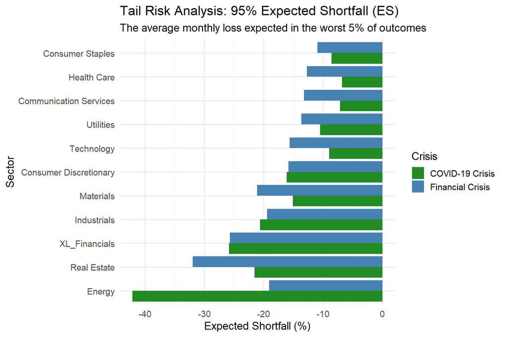

```r
# Function to calculate Quant Risk Metrics
calculate_quant_risk <- function(data, start_date, end_date) {

  # Filter data for the specific crisis
  crisis_returns <- data %>%
    filter(date >= as.Date(start_date) & date <= as.Date(end_date)) %>%
    pivot_wider(names_from = symbol, values_from = monthly_log_return) %>%
    column_to_rownames(var = "date") %>%
    as.matrix() %>%
    as.xts()

  # 1. 95% Historical VaR (What is the 5% worst-case monthly loss?)
  var_95 <- VaR(crisis_returns, p = 0.95, method = "historical")

  # 2. 95% Expected Shortfall (If we hit the 5% tail, what is the average loss?)
  es_95 <- ETL(crisis_returns, p = 0.95, method = "historical")

  # Combine into a tidy tibble
  metrics <- tibble(
    symbol = colnames(var_95),
    VaR_95 = as.vector(var_95) * 100,
    ES_95 = as.vector(es_95) * 100
  )

  return(metrics)
}

# Calculate for both crises
quant_risk_combined <- bind_rows(
  calculate_quant_risk(sector_returns_monthly, crisis_periods$Financial[1], crisis_periods$Financial[2]) %>%
    mutate(Crisis = "Financial Crisis"),
  calculate_quant_risk(sector_returns_monthly, crisis_periods$COVID[1], crisis_periods$COVID[2]) %>%
    mutate(Crisis = "COVID-19 Crisis")
)

# Visualize Expected Shortfall (The 'True' Tail Risk)
ggplot(quant_risk_combined, aes(x = reorder(symbol, ES_95), y = ES_95, fill = Crisis)) +
  geom_bar(stat = "identity", position = "dodge") +
  coord_flip() +
  labs(
    title = "Tail Risk Analysis: 95% Expected Shortfall (ES)",
    subtitle = "The average monthly loss expected in the worst 5% of outcomes",
    x = "Sector",
    y = "Expected Shortfall (%)",
    fill = "Crisis"
  ) +
  scale_fill_manual(values = c("Financial Crisis" = "steelblue", "COVID-19 Crisis" = "forestgreen")) +
  theme_minimal(base_size = 14)
```

## Risk-Return Profile

This scatter plot highlights a clear shift in sector risk–return dynamics between the two crises. During the Financial Crisis (blue triangles), nearly all sectors lie in the negative-return region, with elevated volatility and especially severe outcomes for Financials and Real Estate. This clustering reflects the prolonged, systemic nature of the GFC, where higher risk was consistently paired with worse returns.

In contrast, the COVID-19 Crisis (green circles) shows an upward shift in returns and greater cross-sector dispersion. Most sectors achieved positive mean monthly returns despite moderate volatility, indicating a rapid recovery. Technology and Communication Services exhibit strong returns with relatively lower risk, while Energy stands out as a high-volatility outlier. Overall, the chart underscores the persistent damage of the GFC versus the short-lived but volatile shock of COVID-19.

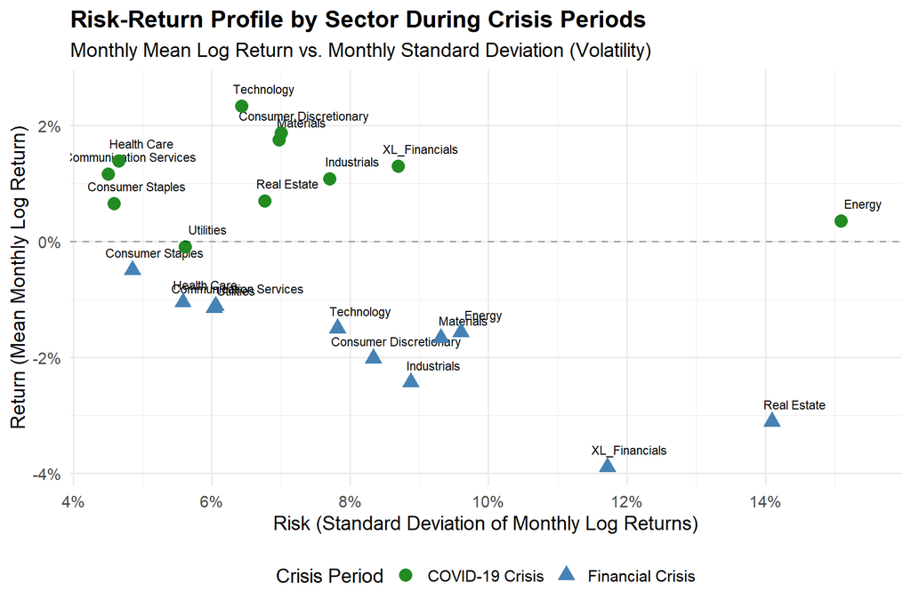

```r
# Risk/Return Scatter Plot
ggplot(sector_performance_combined, aes(x = Std_Dev, y = Mean_Return, color = Crisis)) +
  geom_text(
    aes(label = symbol),
    size = 3,
    color="black",
    nudge_x = 0.00325, # to right
    nudge_y = 0.003 # up
  ) +
  geom_point(aes(shape = Crisis), size = 4) +
  labs(
    title = "Risk-Return Profile by Sector During Crisis Periods",
    subtitle = "Monthly Mean Log Return vs. Monthly Standard Deviation (Volatility)",
    x = "Risk (Standard Deviation of Monthly Log Returns)",
    y = "Return (Mean Monthly Log Return)",
    color = "Crisis Period",
    shape = "Crisis Period"
  ) +
  geom_hline(yintercept = 0, linetype = "dashed", color = "black", alpha = 0.3) +
  scale_x_continuous(labels = percent) +
  scale_y_continuous(labels = percent) +
  scale_color_manual(values = c("Financial Crisis" = "steelblue", "COVID-19 Crisis" = "forestgreen")) +
  theme_minimal(base_size = 14) +
  theme(legend.position = "bottom", plot.title = element_text(face = "bold"))
```

# Macroeconomic Context

These sector-level dynamics unfolded against starkly different macroeconomic backdrops. The following charts examine key economic indicators that shaped market conditions during each crisis period.

## Labor Markets and Monetary Policy

This chart contrasts labor market dynamics and monetary policy across the two crises. During the Financial Crisis (gray shading), the labor market deteriorates gradually: the unemployment rate rises steadily to above 10%, while payroll growth declines into negative territory and remains weak for several years. This slow erosion reflects the prolonged fallout from the housing and credit collapse.

In contrast, the COVID-19 shock (green shading) is marked by an abrupt, unprecedented break. Unemployment spikes almost instantly to over 14%, and payroll growth collapses to nearly −15% in a single month, capturing the sudden halt caused by lockdowns. The Fed Funds Rate highlights the policy difference: rates were cut progressively during the GFC, whereas they were already near zero before COVID, forcing an immediate emergency response to stabilize the economy.

```r
# Key US Economic Indicators (Unemployment, Fed Funds, Year-over-Year Payrolls)
dy_graph1_data <- fred_data_analysis %>%
  select(date, UNRATE_Level, FEDFUNDS_Level, PAYEMS_YoY) %>%
  drop_na()

fred_data_xts1 <- xts(
  x = dy_graph1_data %>% select(-date),
  order.by = dy_graph1_data$date
)

trans_steelblue <- rgb(70/255, 130/255, 180/255, alpha = 0.2)
trans_forestgreen <- rgb(34/255, 139/255, 34/255, alpha = 0.2)

dygraph(fred_data_xts1, main = "Key US Economic Indicators (2000-Present): Labor and Policy") %>%
  dyRangeSelector() %>%
  dyShading(from = "2007-12-01", to = "2009-06-30", color = trans_steelblue, axis = "x") %>%
  dyShading(from = "2020-02-01", to = "2021-04-30", color = trans_forestgreen, axis = "x") %>%
  dyLegend(show = "always", width = 300) %>%
  dySeries("UNRATE_Level", label = "Unemployment Rate (%)") %>%
  dySeries("FEDFUNDS_Level", label = "Fed Funds Rate (%)") %>%
  dySeries("PAYEMS_YoY", label = "Payroll Growth (YoY %)")
```

[interactive chart not shown]

## Consumer Sentiment and Inflation Dynamics

This chart compares consumer sentiment and inflation across the two crisis periods. The Consumer Sentiment Index (green line) declines sharply in both episodes, but the pattern differs: during the Financial Crisis (gray shading), sentiment falls deeply and recovers only gradually over several years, while during the COVID-19 shock (green shading), sentiment drops abruptly from elevated levels, reflecting the sudden uncertainty triggered by the pandemic. In both cases, consumer confidence deteriorates significantly, though the COVID decline is more immediate.

The key distinction emerges in CPI inflation (blue line). During the Financial Crisis, inflation trends downward and briefly turns negative, signaling deflationary pressure from collapsing demand. In contrast, during and after the COVID-19 shock, inflation remains positive and subsequently accelerates, driven by supply disruptions and unprecedented fiscal and monetary stimulus. This divergence underscores the fundamentally different economic mechanisms behind the two crises: a demand-driven financial collapse versus a shock combining supply constraints with aggressive policy intervention.

```r
# Key US Economic Indicators (Consumer Sentiment, CPI YoY)
dy_graph2_data <- fred_data_analysis %>%
  select(date, UMCSENT_Level, CPIAUCSL_YoY) %>%
  drop_na()

fred_data_xts2 <- xts(
  x = dy_graph2_data %>% select(-date),
  order.by = dy_graph2_data$date
)

dygraph(fred_data_xts2, main = "Key US Economic Indicators (2000-Present): Sentiment and Inflation") %>%
  dyRangeSelector() %>%
  dyShading(from = "2007-12-01", to = "2009-06-30", color = trans_steelblue, axis = "x") %>%
  dyShading(from = "2020-02-01", to = "2021-04-30", color = trans_forestgreen, axis = "x") %>%
  dyLegend(show = "always", width = 300) %>%
  dySeries("UMCSENT_Level", label = "Consumer Sentiment Index") %>%
  dySeries("CPIAUCSL_YoY", label = "CPI Inflation (YoY %)")
```

[interactive chart not shown]

# Sector-Specific Deep Dive

To illustrate these broader patterns in greater detail, we now examine specific sectors and their relationship to global market forces, return distributions, and cross-sector correlations.

## Energy Sector vs. Global Indicators

[figure not shown]

```r
# Filter Sector Data to XLE and calculate cumulative simple returns
xle_cum_returns <- data %>%
  filter(symbol == "XLE") %>%
  select(date, adjusted) %>%
  tq_mutate(
    select = adjusted,
    mutate_fun = ROC,
    type = "discrete",
    col_rename = "daily_return"
  ) %>%
  mutate(
    XLE_Cumulative_Return = cumprod(1 + daily_return)
  ) %>%
  select(date, XLE_Cumulative_Return)

macro_plot_data <- fred_data_wide %>%
  select(date, WTISPLC, DEXUSEU) %>%
  drop_na() %>%
  mutate(
    WTISPLC_Index = WTISPLC / first(WTISPLC),
    DEXUSEU_Index = DEXUSEU / first(DEXUSEU)
  )

# date is between 2005-01-01 and covids end
combined_index_data <- xle_cum_returns %>%
  inner_join(macro_plot_data, by = "date") %>%
  filter(
    date >= as.Date("2005-01-01") & date <= as.Date("2021-12-31")
  ) %>%
  pivot_longer(
    cols = ends_with("_Index") | ends_with("Return"),
    names_to = "Series",
    values_to = "Index_Value"
  ) %>%
  group_by(Series) %>%
  mutate(Index_Value = Index_Value / first(Index_Value))

# 4. Plot the comparison
ggplot(combined_index_data, aes(x = date, y = Index_Value, color = Series)) +
  geom_line(linewidth = 1) +
  labs(
    title = "Energy Sector (XLE) vs. Global Indicators",
    subtitle = "Indexed Performance Across Two Crises (Index Value = 1.0 on 2005-01-01)",
    x = "Date",
    y = "Indexed Value (Relative to 2005-01-01)",
    color = "Series"
  ) +
  scale_y_continuous(labels = dollar) +
  scale_color_manual(
    values = c("XLE_Cumulative_Return" = "#2ecc71", "WTISPLC_Index" = "#e74c3c", "DEXUSEU_Index" = "#3498db"),
    labels = c("XLE_Cumulative_Return" = "XLE Sector ETF", "WTISPLC_Index" = "Crude Oil Price", "DEXUSEU_Index" = "EUR/USD Rate")
  ) +
  theme_minimal(base_size = 14) +
  annotate("rect", xmin = as.Date("2007-12-01"), xmax = as.Date("2009-06-30"), ymin = -Inf, ymax = Inf, alpha = 0.1, fill = "steelblue", alpha=.95) +
  annotate("rect", xmin = as.Date("2020-02-01"), xmax = as.Date("2021-04-30"), ymin = -Inf, ymax = Inf, alpha = 0.1, fill = "forestgreen", alpha=.95) +
  theme(legend.position = "bottom", plot.title = element_text(face = "bold"))
```

## Distribution of Monthly Sector Returns

This boxplot compares the distribution of monthly sector returns across the two crises, highlighting differences in median performance, volatility, and tail risk. During the Financial Crisis (blue boxes), most sectors display lower medians and wider interquartile ranges, indicating sustained negative pressure and elevated volatility—most notably in Financials, Real Estate, Industrials, and Energy. The frequent and deep negative outliers reflect the prolonged and systemic nature of losses during the GFC.

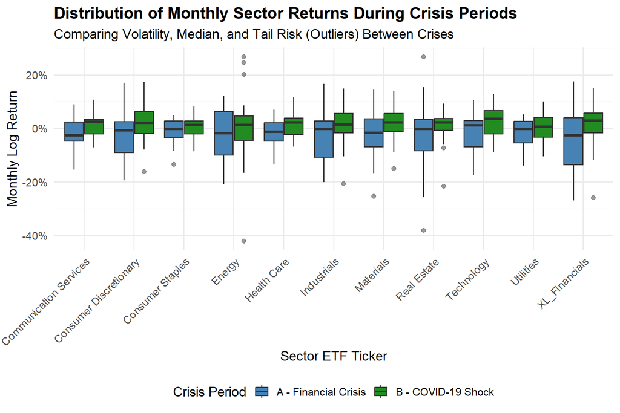

```r
# Filter and label monthly returns
financial_start <- as.Date("2007-12-01")
financial_end <- as.Date("2009-06-30")
covid_start <- as.Date("2020-02-01")
covid_end <- as.Date("2021-09-30")

crisis_returns_filtered <- sector_returns_monthly %>%
  filter(
    (date >= financial_start & date <= financial_end) |
    (date >= covid_start & date <= covid_end)
  ) %>%
  mutate(
    Crisis = case_when(
      date >= financial_start & date <= financial_end ~ "A - Financial Crisis",
      date >= covid_start & date <= covid_end ~ "B - COVID-19 Shock",
      .default = "Other"
    )
  )

ggplot(crisis_returns_filtered, aes(x = symbol, y = monthly_log_return, fill = Crisis)) +
  geom_boxplot(position = position_dodge(width = 0.8), outlier.alpha = 0.5) +
  labs(
    title = "Distribution of Monthly Sector Returns During Crisis Periods",
    subtitle = "Comparing Volatility, Median, and Tail Risk (Outliers) Between Crises",
    x = "Sector ETF Ticker",
    y = "Monthly Log Return",
    fill = "Crisis Period"
  ) +
  scale_y_continuous(labels = percent) +
  scale_fill_manual(values = c("A - Financial Crisis" = "steelblue", "B - COVID-19 Shock" = "forestgreen")) +
  theme_minimal(base_size = 14) +
  theme(
    legend.position = "bottom",
    plot.title = element_text(face = "bold"),
    axis.text.x = element_text(angle = 45, hjust = 1)
  )
```

## Portfolio Diversification Effects

Finally, we assess how crisis conditions affected portfolio diversification through cross-sector correlations. This analysis reveals critical differences in the effectiveness of diversification strategies during each crisis period.

### Sector Correlation Heatmaps

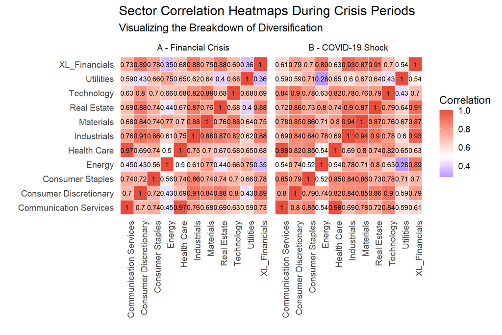

```r
# Function to prepare data for correlation calculation and plotting
prepare_correlation_data <- function(start_date, end_date, crisis_name) {
  crisis_returns_filtered <- sector_returns_monthly %>%
    filter(date >= as.Date(start_date) & date <= as.Date(end_date)) %>%
    drop_na()

  returns_xts <- crisis_returns_filtered %>%
    pivot_wider(names_from = symbol, values_from = monthly_log_return) %>%
    column_to_rownames(var = "date") %>%
    as.matrix() %>%
    as.xts()

  cor_matrix <- cor(returns_xts)

  cor_long <- cor_matrix %>%
    as.data.frame() %>%
    rownames_to_column(var = "Sector_X") %>%
    pivot_longer(cols = -Sector_X, names_to = "Sector_Y", values_to = "Correlation") %>%
    mutate(Crisis = crisis_name)

  return(cor_long)
}

# Calculate correlation for BORHT crises
cor_gfc <- prepare_correlation_data(
  crisis_periods$Financial[1],
  crisis_periods$Financial[2],
  "A - Financial Crisis"
)

cor_covid <- prepare_correlation_data(
  crisis_periods$COVID[1],
  crisis_periods$COVID[2],
  "B - COVID-19 Shock"
)

# Combine the two correlation tibbles for a side-by-side
cor_combined <- bind_rows(cor_gfc, cor_covid)


ggplot(cor_combined, aes(x = Sector_X, y = Sector_Y, fill = Correlation)) +
  geom_tile(color = "white") +
  geom_text(aes(label = round(Correlation, 2)), color = "black", size = 3) +
  facet_wrap(~ Crisis) +
  labs(
    title = "Sector Correlation Heatmaps During Crisis Periods",
    subtitle = "Visualizing the Breakdown of Diversification",
    x = "",
    y = "",
    fill = "Correlation"
  ) +
  scale_fill_gradient2(
    low = "blue",
    mid = "white",
    high = "#e74c3c",
    midpoint = 0.5,
    limit = c(min(cor_combined$Correlation), 1)
  ) +
  theme_minimal(base_size = 14) +
  theme(
    axis.text.x = element_text(angle = 90, vjust = 1, hjust = 1),
    panel.grid.major = element_blank()
  )
```

# Conclusion

This analysis demonstrates that while both crises were historically severe, they represented fundamentally different **risk regimes**. The Global Financial Crisis was a crisis of **duration and systemic persistence**, characterized by a slow decay in labor markets and a multi-year recovery period. In contrast, the COVID-19 shock was a crisis of **convexity and intensity**, featuring unprecedented spikes in tail risk and a rapid, policy-supported reversal.

## Model Risk & Limitations

As part of a robust **Model Risk Management (MRM)** framework, it is critical to identify the inherent limitations of this analysis. No model perfectly captures the complexity of market dynamics, particularly during structural regime shifts.

- **Asset Class Concentration:** This report focuses exclusively on **Equity Sector ETFs**. Consequently, it does not account for the diversification benefits of a multi-asset portfolio (e.g., Investment Grade Bonds, Preferred Stocks, or Commodities). In a true institutional stress test, the inclusion of fixed-income instruments would likely dampen the observed **Expected Shortfall**, as high-quality bonds often exhibit “flight-to-quality” behavior during equity drawdowns.
- **Survival & Selection Bias:** The analysis is restricted to funds with data availability dating back to 2000. By utilizing specific established ETFs (like the Select Sector SPDRs), the model may suffer from **selection bias**, as it does not account for funds or companies that were delisted or became insolvent during the 2008 crisis.
- **Historical Simulation Constraints:** The **Expected Shortfall** is calculated using the **Historical Simulation** method. This approach assumes that the past is a reliable guide to the future. It may fail to predict “Black Swan” events that have no historical precedent or occur under different liquidity and leverage conditions than those observed in the 2007–2021 window.

## Defined Math

### Log Returns

We utilize log returns for statistical symmetry and time-additivity:
$$r_t = \ln\left(\frac{P_t}{P_{t-1}}\right)$$

### Expected Shortfall (ES)

Calculated using the Historical Simulation method at the 95% confidence level ($\alpha = 0.05$):
$$ES_\alpha = E[X | X \leq VaR_\alpha]$$
This represents the expected value of the loss, given that the loss has exceeded the Value-at-Risk threshold.